# 1A - Exploring Abundance data

Orsolya Bajer-Molnar

2025-08-05

[output not shown]

# Observing data trends

To see if there are general trends in the data, I started by searching for observable trends and alignments in the data and overlaying different metadata.

## PCA approach

My first approach was to test the PCA approach, so i checked if the data showed Gaussian distribution

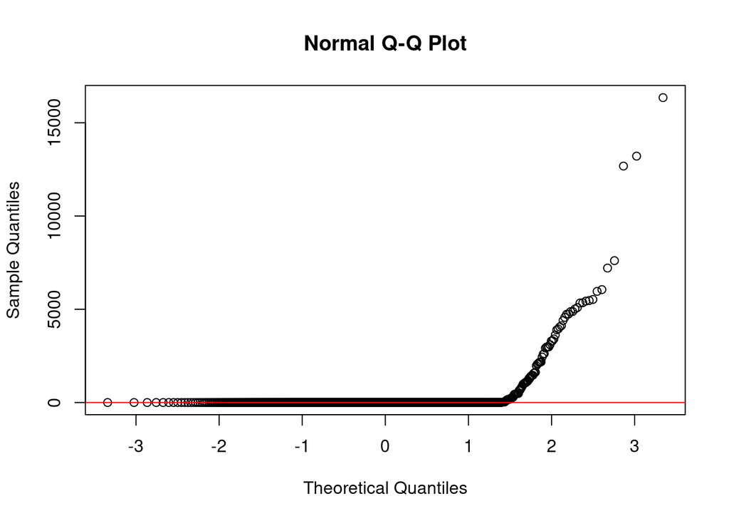

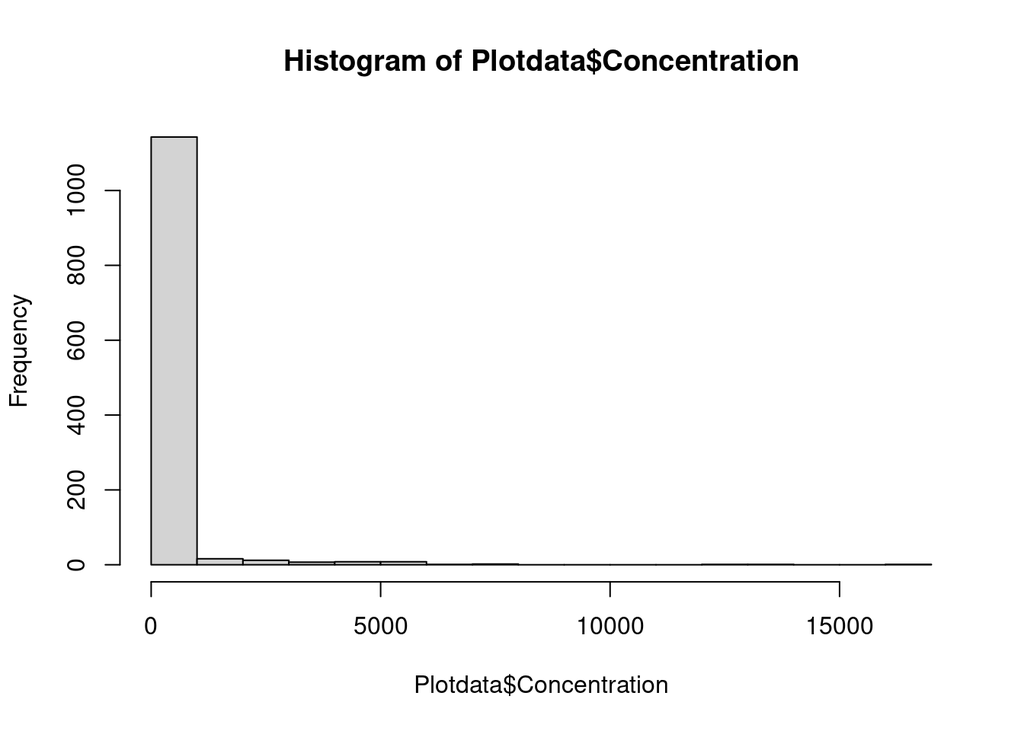

Data is zero-inflated, so PCA isn’t a good approach. Transformation had been discussed, but I decided against it for 2 reasons:

1. log-transformation cannot be done becuase of the 0 values
2. complex transformations could mask existing trends

**PCA approach was abandoned in favor of one more fitting zero-inflated data**

## Non-metrix Multidimensional Scaling (NMDS)

I chose this methods to better deal with zero-inflated data, as an alternative to PCA. I followed the method and recommendations from this reference https://jkzorz.github.io/2019/06/06/NMDS.html

### Raw data

I first entered the raw data into the analyses, and let the model calculate the distances. I removed all row with 0 sum from the df and then ran the model set to the defaul **Bray-Curtis** distance

```r
tpm_matrixabund <- Plotdata %>%
  pivot_wider(names_from = Target.Name, values_from = Concentration, values_fill = 0)
tpm_matrixabund<-na.omit(tpm_matrixabund)

NMDSdata<-tpm_matrixabund%>%
  select(Adenovirus, Enterovirus, `Influenza A`, `Influenza B`, Norovirus, RSV, Rhinovirus, `SARS-CoV-2`)

NMDSdata_nonull<- NMDSdata%>%
  filter(rowSums(.) > 0)

M_NMDSdata_nonull<-as.matrix(NMDSdata_nonull)
set.seed(123)
summary(M_NMDSdata_nonull)
```

```
##    Adenovirus       Enterovirus        Influenza A       Influenza B
##  Min.   :0.00000   Min.   :  0.0000   Min.   :  0.000   Min.   : 0.00000
##  1st Qu.:0.00000   1st Qu.:  0.0000   1st Qu.:  0.000   1st Qu.: 0.00000
##  Median :0.00000   Median :  0.0000   Median :  0.000   Median : 0.00000
##  Mean   :0.01917   Mean   :  0.8252   Mean   :  1.417   Mean   : 0.08095
##  3rd Qu.:0.00000   3rd Qu.:  0.0000   3rd Qu.:  0.000   3rd Qu.: 0.00000
##  Max.   :3.33700   Max.   :220.6000   Max.   :375.400   Max.   :18.24000
##    Norovirus              RSV            Rhinovirus          SARS-CoV-2
##  Min.   :0.0000000   Min.   :    0.0   Min.   :    0.000   Min.   :0.00000
##  1st Qu.:0.0000000   1st Qu.:    0.0   1st Qu.:    0.000   1st Qu.:0.00000
##  Median :0.0000000   Median :    0.0   Median :    0.000   Median :0.00000
##  Mean   :0.0006754   Mean   :  103.2   Mean   :  147.850   Mean   :0.07616
##  3rd Qu.:0.0000000   3rd Qu.:    0.0   3rd Qu.:    0.013   3rd Qu.:0.05312
##  Max.   :0.0700000   Max.   :16348.4   Max.   :13212.400   Max.   :6.99450
```

```r
nmds<-metaMDS(M_NMDSdata_nonull, distance = 'bray')
```

```
## Square root transformation
## Wisconsin double standardization
## *** Best solution was not repeated -- monoMDS stopping criteria:
##     12: stress < smin
##      8: scale factor of the gradient < sfgrmin
```

```r
nmds
```

```
##
## Call:
## metaMDS(comm = M_NMDSdata_nonull, distance = "bray")
##
## global Multidimensional Scaling using monoMDS
##
## Data:     wisconsin(sqrt(M_NMDSdata_nonull))
## Distance: bray
##
## Dimensions: 2
## Stress:     0
## Stress type 1, weak ties
## Best solution was not repeated after 20 tries
## The best solution was from try 1 (random start)
## Scaling: centring, PC rotation, halfchange scaling
## Species: scores missing
```

The resulting stress is ~ 0, so i tried to use the **Jaccard** distance, which is suitaed better for presence/absence type of matrices

```r
j_nmds<-metaMDS(M_NMDSdata_nonull, distance = 'jaccard')
```

```
## Square root transformation
## Wisconsin double standardization
## *** Best solution was not repeated -- monoMDS stopping criteria:
##     11: stress < smin
##      9: scale factor of the gradient < sfgrmin
```

```r
j_nmds
```

```
##
## Call:
## metaMDS(comm = M_NMDSdata_nonull, distance = "jaccard")
##
## global Multidimensional Scaling using monoMDS
##
## Data:     wisconsin(sqrt(M_NMDSdata_nonull))
## Distance: jaccard
##
## Dimensions: 2
## Stress:     0
## Stress type 1, weak ties
## Best solution was not repeated after 20 tries
## The best solution was from try 3 (random start)
## Scaling: centring, PC rotation, halfchange scaling
## Species: scores missing
```

Resulting stress is still ~ 0

### Manual distance calculation

I then modified the approach a bit, and calculated the distances into a matrix before the nmds comaprison, as well as forcing it to iterate 200 times

**Curtis-Bray distance**

```r
dist_matrix_nmds_abund_bray <- vegdist(NMDSdata_nonull, method = "bray")
nmds_veg_bray <- metaMDS(dist_matrix_nmds_abund_bray, k = 2, trymax = 200)
```

```
## *** Best solution was not repeated -- monoMDS stopping criteria:
##      1: stress < smin
##    199: scale factor of the gradient < sfgrmin
```

```r
nmds_veg_bray
```

```
##
## Call:
## metaMDS(comm = dist_matrix_nmds_abund_bray, k = 2, trymax = 200)
##
## global Multidimensional Scaling using monoMDS
##
## Data:     dist_matrix_nmds_abund_bray
## Distance: bray
##
## Dimensions: 2
## Stress:     9.931226e-05
## Stress type 1, weak ties
## Best solution was not repeated after 200 tries
## The best solution was from try 16 (random start)
## Scaling: centring, PC rotation, halfchange scaling
## Species: scores missing
```

Still shows low stress levels, but worth noting that they are less close to zero than in the raw data version

**Jaccard distance**

```r
dist_matrix_nmds_abund_j <- vegdist(NMDSdata_nonull, method = "jaccard")
nmds_veg_jaccard <- metaMDS(dist_matrix_nmds_abund_j, k = 2, trymax = 200)
```

```
## *** Best solution was not repeated -- monoMDS stopping criteria:
##    200: scale factor of the gradient < sfgrmin
```

```r
nmds_veg_jaccard
```

```
##
## Call:
## metaMDS(comm = dist_matrix_nmds_abund_j, k = 2, trymax = 200)
##
## global Multidimensional Scaling using monoMDS
##
## Data:     dist_matrix_nmds_abund_j
## Distance: jaccard
##
## Dimensions: 2
## Stress:     0.0001251787
## Stress type 1, weak ties
## Best solution was not repeated after 200 tries
## The best solution was from try 84 (random start)
## Scaling: centring, PC rotation, halfchange scaling
## Species: scores missing
```

Still low stress level, but it has the highest of all the methods tested here, so this is the one I went with

I then visualize the results of the final version: **Manual Jaccard distance** calculation, using the scores of the nmds matrix

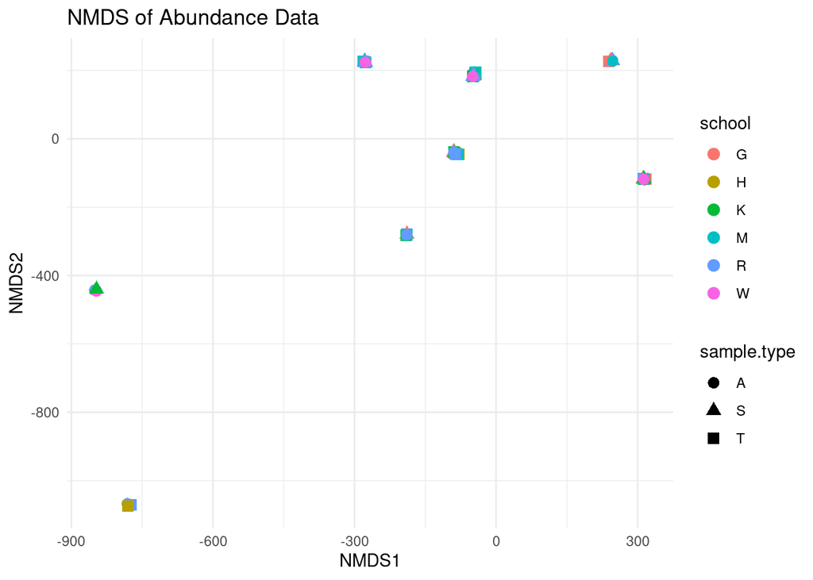

Finally, I test is the metadata columns have an effect on the distances in the matrix

```r
adonis2(dist_matrix_nmds_abund_j ~ school, data = metadata_clean)
```

```
## Permutation test for adonis under reduced model
## Permutation: free
## Number of permutations: 999
##
## adonis2(formula = dist_matrix_nmds_abund_j ~ school, data = metadata_clean)
##           Df SumOfSqs     R2      F Pr(>F)
## Model      5    2.369 0.0198 1.0583  0.346
## Residual 262  117.290 0.9802
## Total    267  119.659 1.0000
```

No effect for school

```r
adonis2(dist_matrix_nmds_abund_j ~ sample.type, data = metadata_clean)
```

```
## Permutation test for adonis under reduced model
## Permutation: free
## Number of permutations: 999
##
## adonis2(formula = dist_matrix_nmds_abund_j ~ sample.type, data = metadata_clean)
##           Df SumOfSqs      R2      F Pr(>F)
## Model      2    1.903 0.01591 2.1418  0.002 **
## Residual 265  117.756 0.98409
## Total    267  119.659 1.00000
## ---
## Signif. codes:  0 '***' 0.001 '**' 0.01 '*' 0.05 '.' 0.1 ' ' 1
```